# Test a Perpetual Phenomenon

Q1. What is our independent variable? What is our dependent variable?.

The independent variable is the two different conditions i.e. group of congruent and incongruent words. The dependent variable is time required to identify the colour of words of two different conditions.

Q2. What is an appropriate set of hypotheses for this task? What kind of statistical test do you expect to perform? Justify your choices.

Since we do not know population parameters we need to perform the t test. This is the case of repeated measure design where the same subject is given two different tests. We can perform the paired t tests. The difference between the times required to identify the congruent words and incongruent words can be calculated. The null hypothesis could be the population means of the two groups are same and alternate hypothesis is that the population means are not equal.

$$H_O:\mu_{Con}=\mu_{Incon}$$
$$H_A:\mu_{Con}\neq\mu_{Incon}$$

Above,  
$H_O$ is the null hypothesis  
$H_A$ is the alternate hypothesis  
$\mu_{Con}$ is the mean of the time required to identify the color of the congruent group of words.  
$\mu_{Incon}$ is the mean of the time required to indentify the color of the incongruent group of words.

Q3. Report some descriptive statistics regarding this dataset. Include at least one measure of central tendency and at least one measure of variability..

##### Measure of the Centrality

```
##    Congruent      Incongruent
##  Min.   : 8.63   Min.   :15.69
##  1st Qu.:11.90   1st Qu.:18.72
##  Median :14.36   Median :21.02
##  Mean   :14.05   Mean   :22.02
##  3rd Qu.:16.20   3rd Qu.:24.05
##  Max.   :22.33   Max.   :35.26
```

The above table shows the summary stastistics of the data set provided which involves five number summary and the mean for the congruent and incongruent groups.The most important measure of the centrality is median. The median for the congruent group is 14.36 seconds and incongruent group is 21.02 seconds. This stastistics clearly shows that incogruent group takes more time to read the color of incongruent words.

##### Measure of the Variablity

The most important measure of the variability is the stadard deviation. This signifies the average distance from the mean. For congruent group of people the standard deviation is 3.56 seconds and for incongruent group the standard deviation is 4.8 seconds. The stadard deviation is not robust measure of variability as it is affectd by the outliers. The inter quratile range could be another measure of the variability as it is not affected by the outliers. The inter quartile range for congruent groups is 4.31 seconds and for incongruent group 5.33 seconds.

Q4. One or two visualizations have been created that show off the data, including comments on what can be observed in the plot or plots.

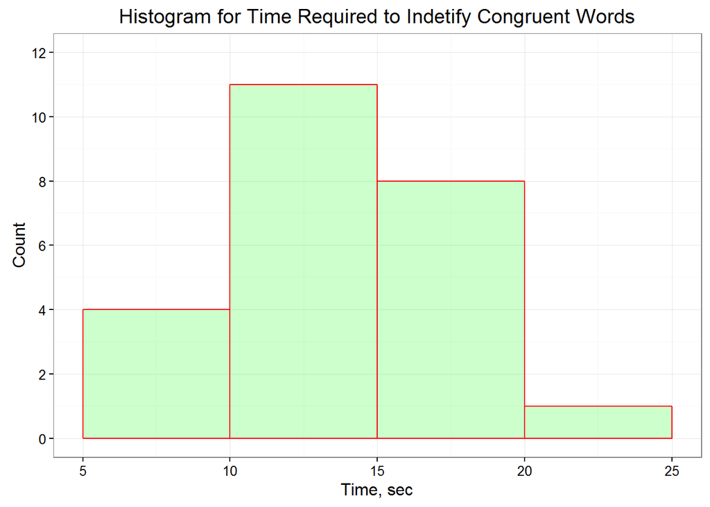

The above histogram show the time rquired to indentify the color of the congruent words. The distribution looks approximately normally distributed with peak occuring at 10-15 seconds, ie. mode of the data.

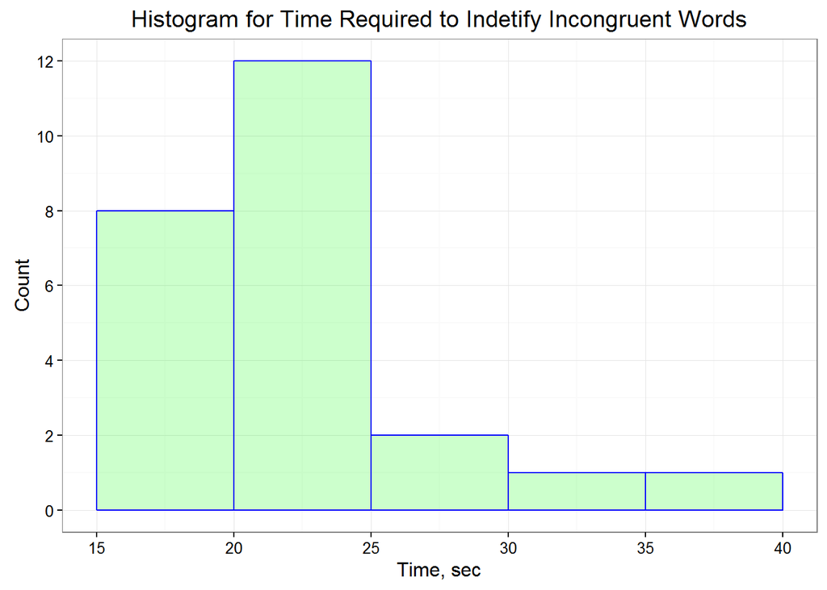

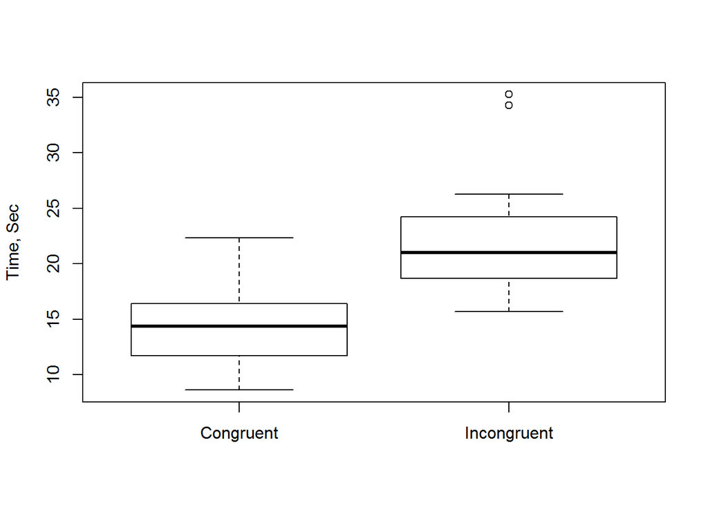

The boxplot also show that all time paramters like min, median, max etc required to indetify color of the incongruent words are more than the time required for indetifying the color of the cogruent words. The two outliers can bee seen in incongrunet group are making the incogruent histogram positively skewed.

Q5. Now, perform the statistical test and report your results. What is your confidence level and your critical statistic value? Do you reject the null hypothesis or fail to reject it? Come to a conclusion in terms of the experiment task. Did the results match up with your expectations?

$$\overline{x}_{Con}= 14.0511$$

$$\overline{x}_{Incon}= 22.0159$$

$$\overline{x}_{Con}-\overline{x}_{Incon}= -7.9648$$

$$S=4.8648$$

$${SE} = \frac{S}{\sqrt{n}}=\frac{4.8648}{\sqrt{24}}=0.993$$

$$t=\frac{{\overline{x}_{Con}}-{\overline{x}_{Incon}}}{SE}$$

$$t=-8.0209$$

for conventional $95\%$ confidence level,

$$t_{critical} = \pm 2.069$$

The t value falls in to the critical region. We reject the null hypothesis. The means of the two groups are coming from two different population and not by chance. The results does match with my expectations.

The t test is laso performed using R software to validate the manual calculation and the output is shown below.

```
##
##  Paired t-test
##
## data:  stroopdata$Congruent and stroopdata$Incongruent
## t = -8.0207, df = 23, p-value = 4.103e-08
## alternative hypothesis: true difference in means is not equal to 0
## 95 percent confidence interval:
##  -10.019028  -5.910555
## sample estimates:
## mean of the differences
##               -7.964792
```

Q6. Optional: What do you think is responsible for the effects observed? Can you think of an alternative or similar task that would result in a similar effect? Some research about the problem will be helpful for thinking about these two questions!.

The time required to name the color of the word is more for the incogruent word than congruent word this because of the confusion created in the mind. Incongruent words requires more attention to be provided towards the color of the ink than the word itself. This kind of similar effect may be observed if two similar shapes but of different sizes written with “small” and “large” words.